# JUPYTER NOTEBOOK: INTRODUCTION

[figure not shown]

A "Jupyter notebook" denote documents that contain both **code** and **rich text elements**, such as figures, links, equations, etc.

These documents are the ideal place to bring together an **analysis** description, since they contain:

- description;
- code (to be executed);
- results;

*Let's see a quick example*

### The Normal Distribution

$$ f(x) = \frac{1}{\sigma \sqrt{ 2 \pi}} e^{-\frac{1}{2}(\frac{x - \mu}{\sigma})^2} $$

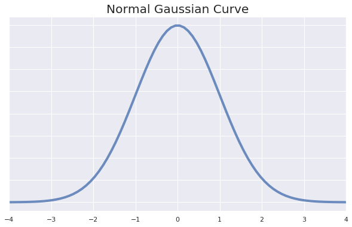

```python
import numpy as np
import matplotlib.pyplot as plt
from scipy.stats import norm
import seaborn as sns
sns.set(color_codes=True)
%matplotlib inline

mu = 0
sigma = 1

x = np.linspace(mu - 5*sigma, mu + 5*sigma, 100)
y = norm.pdf(x, mu, sigma)

fig, ax = plt.subplots(figsize=(9,6))
plt.style.use('fivethirtyeight')
ax.plot(x, y, alpha=0.8)
ax.set_xlim([-4,4])
ax.set_yticklabels([])
_ = ax.set_title('Normal Gaussian Curve')
```

## A little bit of background

- In 2001 Fernando Pérez starts developing IPython (interactive Python)
- The concept of a notebook, which contains ordinary text and calculation and/or graphics, is **not new**
- The developer of Jupyter Notebook was an avid users of the **Maple** worksheets and **Mathematica** notebooks(created in 1988)
- The first prototype of IPython notebook was released in 2011
- In 2014, Project Jupyter started as a spin-off project from IPython. IPython is now the name of the Python backend, which is also known as the **kernel**

## Jupyter HUB

To recap:

- a Jupyter Notebook App is a **web application** for running and sharing notebook documents.
- a notebook document can contain **code** and other elements that are executable via a **kernel**. It can also contain rich text and **figures**.
- a kernel executes the code in a notebook document. A kernel can live within **environment** (e.g. a conda environment)

*So what is a Jupyter HUB?*

[figure not shown]

## Use Jupyter Notebook on your own

#### Download and install Anaconda

https://docs.conda.io/projects/conda/en/latest/user-guide/install/linux.html

```
user@methada2020:~$ bash Anaconda-latest-Linux-x86_64.sh
```

#### Create new environment named **myenv**

```
user@methada2020:~$ conda create -n myenv python=3.6
```

#### Activate environment **myenv**

```
user@methada2020:~$ conda activate myenv
```

#### Install Jupyter Lab

```
(myenv)user@methada2020:~$ conda install -c conda-forge jupyterlab
```

```
(myenv)user@methada2020:~$ conda install -c anaconda numpy scipy matplotlib
```

#### Show installed packages (and version)

```
(myenv)user@methada2020:~$ conda env export
```

#### Run Jupyter Lab

```
(myenv)user@methada2020:~$ jupyter lab
```

#### Deactivate environment

```
(myenv)user@methada2020:~$ conda deactivate
```

## Training school setup

#### Jupyter HUB server

```
http://methada2020.uv.es:8888
```

#### VESPUCCI

```
http://methada2020.uv.es:5555/graphql
```

#### Documentation

```
https://github.com/jtomasmatus/methada2020
```

## Modify your password

- Login with the given username and password
- Start a new Terminal Session
- Type into the terminal the following command to change password

  ```
  userXX@blablabla:~$ passwd

  userXX@blablabla:~$ Changing password for userXX.

  userXX@blablabla:~$ Current password:

  userXX@blablabla:~$ New password:

  userXX@blablabla:~$ Retype new password:

  userXX@blablabla:~$ passwd: password updated successfully
  ```